# 来一发megui吧！

### 2.3.3 **重要** 调整声音延迟

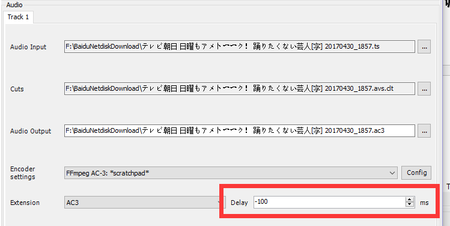

若声音比画面晚出现，则为负数，反之为正数 一般情况不超过100ms（不确定的话，请先剪2分钟测试一下）

### 2.3.4 压制

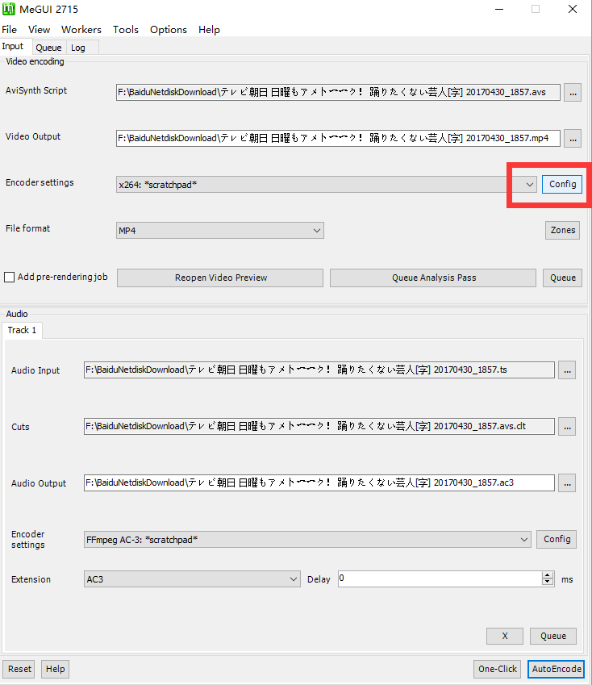

[figure not shown]

设置压制参数，这里只需修改码率，一般小档800足矣

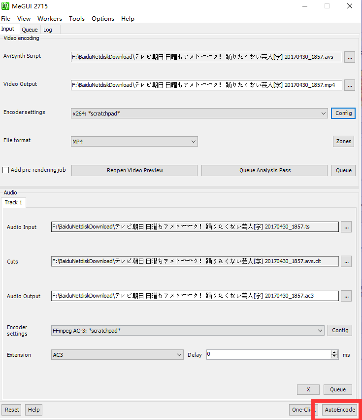

[figure not shown]

选择无尺寸要求，点队列，开始压制

## 2.4 上传（略）

# 3 在字幕中加入图片

本方法，是通过在ass字幕文件中添加语句，设定好位置大小和时间后，在avs中调用dll方可添加成功

## 3.1 准备图片素材

- 保存为png格式
- 在ps中设置好尺寸和透明度，并记好数据
- 位置和文件名必须全英文

## 3.2 在Aegisub中设置位置

首先在第一行添加如下代码 ，并设置出现和消失的时间

```
{\p1\1img(H:/xxx.png)\bord0\shad0\pos(x,y)}m 0 0 l 0 100 l 230 100 l 230 0\N
```

`m 0 0 l 0 100 l 230 100 l 230 0`部分为尺寸设置

**说明：图片大小严格按照做图时的来输入，否则会出现重复图案的情况**

效果如图所示

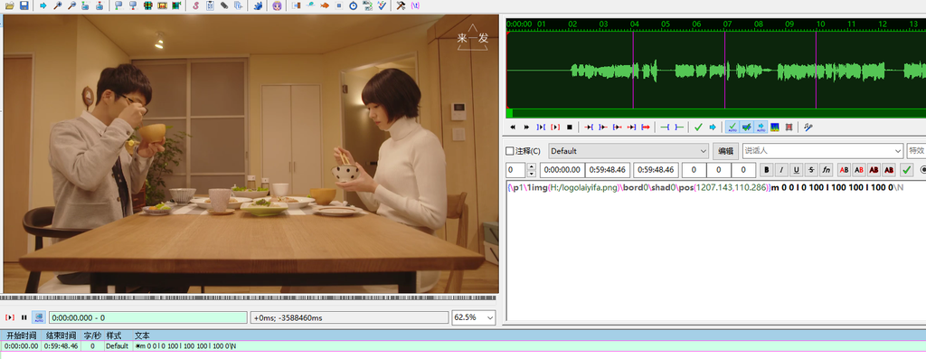

> **想要aegisub可以显示图片，需要进行一些设置**
- 首先在根目录，放置VSFilterMod.dll

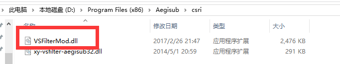

- 在软件中要到设置，按照如图所示选择该滤镜即可

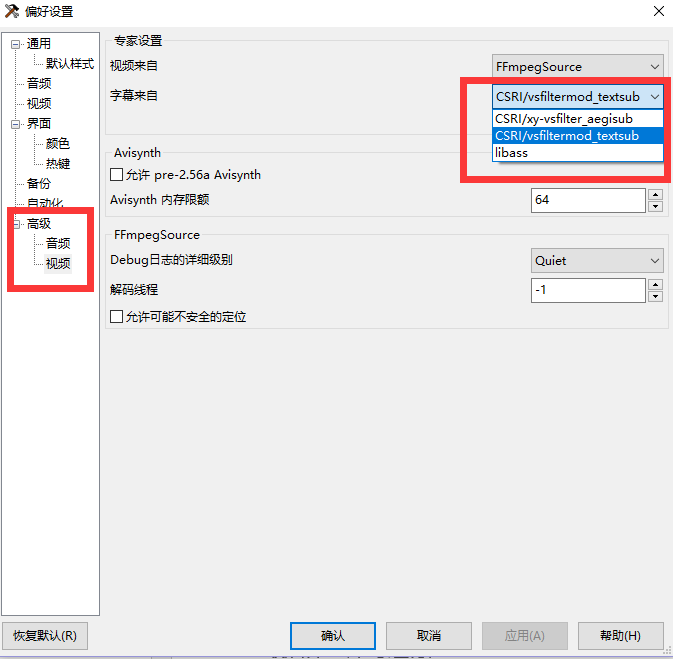

## 3.3 脚本代码设置

1. 添加VSFilterMod.dll文件
2. 字幕那里添加3个字母，注意大小写

[figure not shown]

最后保存即可进行压制

# 4 压制片头

只需在avs脚本添加如下代码

```
A=LWLibavVideoSource("F:\片头名.mp4",threads=1).LanczosResize(1280,720).AssumeFPS("ntsc_video")
B=LWLibavAudioSource("F:\ 片头名.ac3").ResampleAudio(48000)
E=AudioDub(A,B)

C=LWLibavVideoSource("F:\正片名.mp4",threads=1).LanczosResize(1280,720).AssumeFPS("ntsc_video").textsubmod("F:\字幕名 .ass")
D=LWLibavAudioSource("F:\ 片名.ac3").ResampleAudio(48000)
F=AudioDub(C,D)
return E+F
```

```
## 说明
## A=片头  B=片头音频 E=整个片头影音
## C=正片  D=正片音频 F=整个正片影音
## E+F=一个完整的视频
```

效果如下

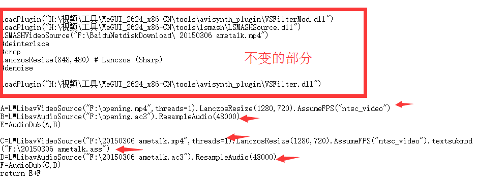

> 注意要点

```
素材 : 分辨率、x264参数要一样，音频部分:编码方式、采样率要一样！！（音频可使用小丸工具箱统一提取压制）
引用地址和文件名：全英文！！最好的办法是放在某盘的根目录下
```

[^1]: 如果装了别的解码比如Win7专用Win7codecs解码包就不用再安装额外的解码了免得有冲突
[^2]: 笔者的数据，根据软件版本和电脑不同数据可能不同，具体请自行测试